# NBA over/under historical odds

24 August, 2023

(This was written in a hurry, do not use it as a “good code” sample!)

```r
knitr::opts_chunk$set(echo = TRUE, message = FALSE, warning = FALSE)
```

```r
library(dplyr)
library(ggplot2)

url <- 'https://www.rotowire.com/betting/nba/tables/games-archive.php'

raw <- jsonlite::read_json(url)
df_raw <- purrr::map_df(raw, tibble::as_tibble)
df <- df_raw %>% select(
  date = game_date,
  home = home_team_stats_id,
  away = visit_team_stats_id,
  prediction = game_over_under,
  total
)
df <- df[df$prediction != "", ]
df <- df %>% mutate(
  prediction = as.numeric(prediction),
  total = as.numeric(total),
  diff = prediction - total,
  diff_abs = abs(diff),
  diff_percent = round(diff_abs / prediction * 100, 1)
)

df <- df %>% mutate(
  prediction_bin = case_when(
    prediction < 195 ~ "[0, 195)",
    prediction < 200 ~ "[195-200)",
    prediction < 205 ~ "[200-205)",
    prediction < 210 ~ "[205-210)",
    prediction < 215 ~ "[210-215)",
    prediction < 220 ~ "[215-220)",
    prediction < 225 ~ "[220-225)",
    prediction < 230 ~ "[225-230)",
    prediction < 235 ~ "[230-235)",
    prediction < 240 ~ "[235-240)",
    prediction < 245 ~ "[240-245)",
    TRUE             ~ "[245, Inf)"
  )
)
```

Using https://www.rotowire.com/betting/nba/tables/games-archive.php, there are 7518 games from 2017-10-17 00:00:00 to 2023-06-12 00:00:00.

Here’s how the data looks like:

```r
reactable::reactable(df)
```

| date | home | away | prediction | total | diff | diff_abs | diff_percent | prediction_bin |
| --- | --- | --- | --- | --- | --- | --- | --- | --- |
| 2017-10-17 00:00:00 | CLE | BOS | 216 | 201 | 15 | 15 | 6.9 | [215-220) |
| 2017-10-17 00:00:00 | GSW | HOU | 231 | 243 | -12 | 12 | 5.2 | [230-235) |
| 2017-10-18 00:00:00 | DET | CHA | 202 | 192 | 10 | 10 | 5 | [200-205) |
| 2017-10-18 00:00:00 | IND | BKN | 216.5 | 271 | -54.5 | 54.5 | 25.2 | [215-220) |
| 2017-10-18 00:00:00 | ORL | MIA | 205.5 | 225 | -19.5 | 19.5 | 9.5 | [205-210) |
| 2017-10-18 00:00:00 | WAS | PHI | 217.5 | 235 | -17.5 | 17.5 | 8 | [215-220) |
| 2017-10-18 00:00:00 | BOS | MIL | 203 | 208 | -5 | 5 | 2.5 | [200-205) |
| 2017-10-18 00:00:00 | MEM | NOP | 204.5 | 194 | 10.5 | 10.5 | 5.1 | [200-205) |
| 2017-10-18 00:00:00 | DAL | ATL | 199 | 228 | -29 | 29 | 14.6 | [195-200) |
| 2017-10-18 00:00:00 | UTA | DEN | 205 | 202 | 3 | 3 | 1.5 | [205-210) |

[output cut: 7508 more lines]

Mean predicted o/u: 221.3689811  
Mean total score: 221.7376962  
Median predicted o/u: 221.5  
Median total score: 221  
They’re all very very similar

Mean difference between prediction and real score: -0.3687151  
It makes sense that it’s ~0 but it can also be useful to look at the absolute difference between prediction and score.  
Mean absolute difference: 14.4188614

O/U prediction vs total score:

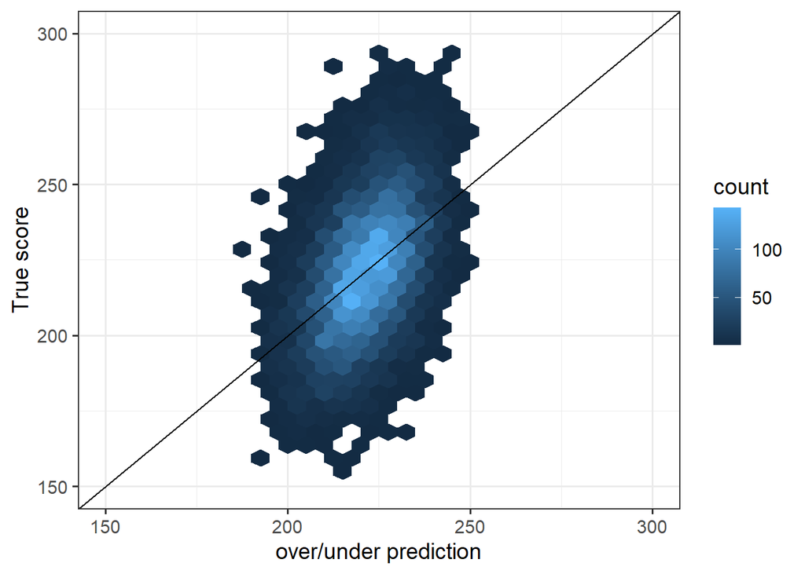

```r
ggplot(df, aes(prediction, total)) +
  geom_hex(binwidth = c(5, 5)) +
  theme_bw(14) +
  scale_x_continuous(limits = c(150, 300)) +
  scale_y_continuous(limits = c(150, 300)) +
  geom_abline(slope = 1, intercept = 0) +
  xlab("over/under prediction") +
  ylab("True score")
```

I added a y=x line for reference. Looks like the predictions are pretty accurate.

Histogram of the difference between real and predicted:

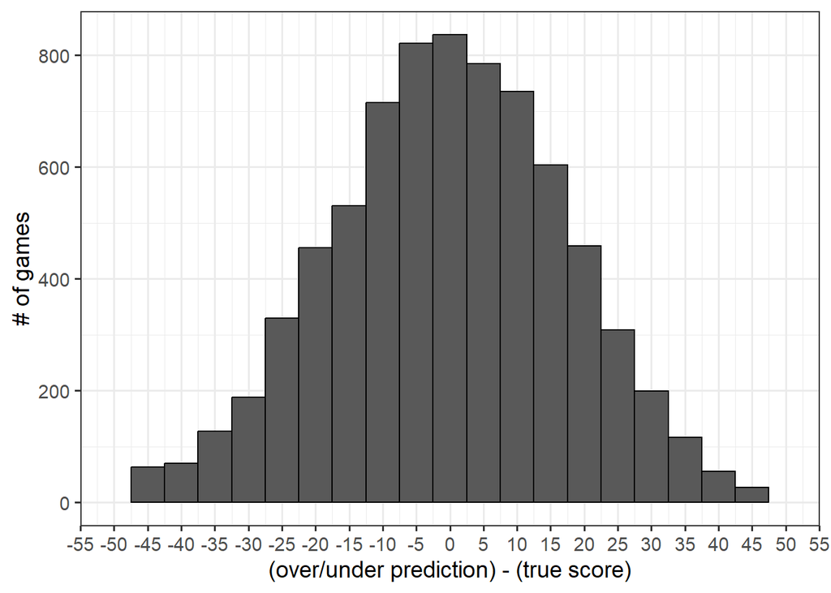

```r
ggplot(df, aes(diff)) +
  geom_histogram(binwidth = 5, color = "black") +
  ggplot2::scale_x_continuous(limits = c(-50, 50), n.breaks = 20) +
  theme_bw(14) +
  xlab("(over/under prediction) - (true score)") +
  ylab("# of games")
```

Same plot but using absolute difference instead:

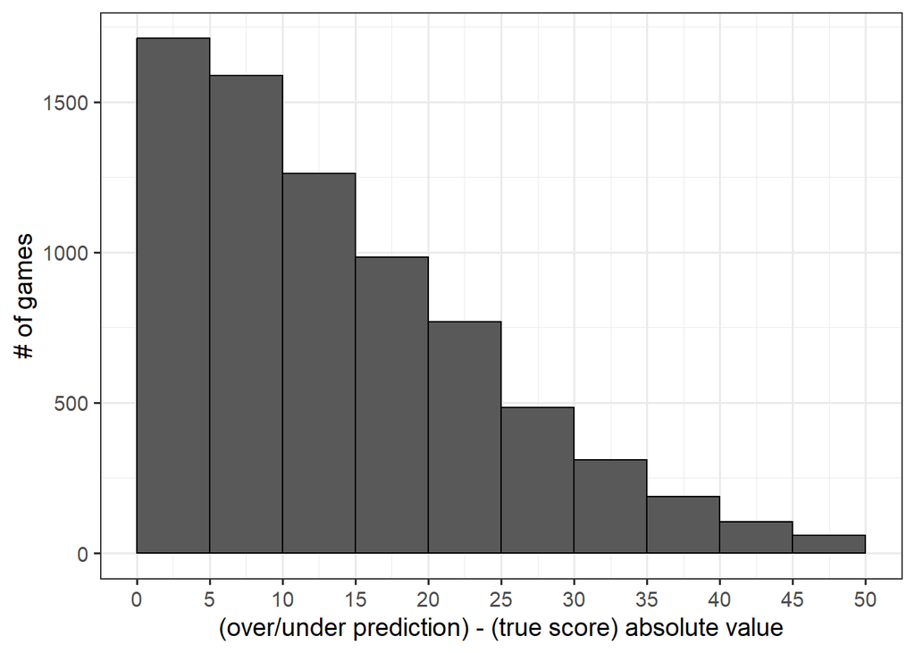

```r
ggplot(df, aes(diff_abs)) +
  geom_histogram(binwidth = 5, color = "black", boundary = 0) +
  ggplot2::scale_x_continuous(limits = c(0, 50), n.breaks = 10) +
  theme_bw(14) +
  xlab("(over/under prediction) - (true score) absolute value") +
  ylab("# of games")
```

Might be interesting to look at the % difference instead of absolute difference (for example, if prediction was 200 and score was 210, the different is 10 and the % difference is 10/200*100 = 5%):

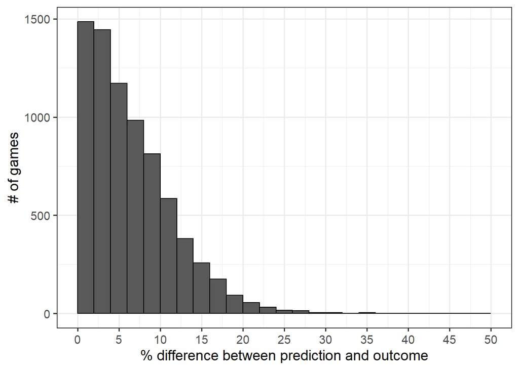

```r
ggplot(df, aes(diff_percent)) +
  geom_histogram(binwidth = 2, color = "black", boundary = 0) +
  ggplot2::scale_x_continuous(limits = c(0, 50), n.breaks = 10) +
  theme_bw(14) +
  xlab("% difference between prediction and outcome") +
  ylab("# of games")
```

I can’t find anything abnormal by looking at the entire dataset. Let’s try grouping the predicted o/u by increments of 5, and then look at the absolute difference:

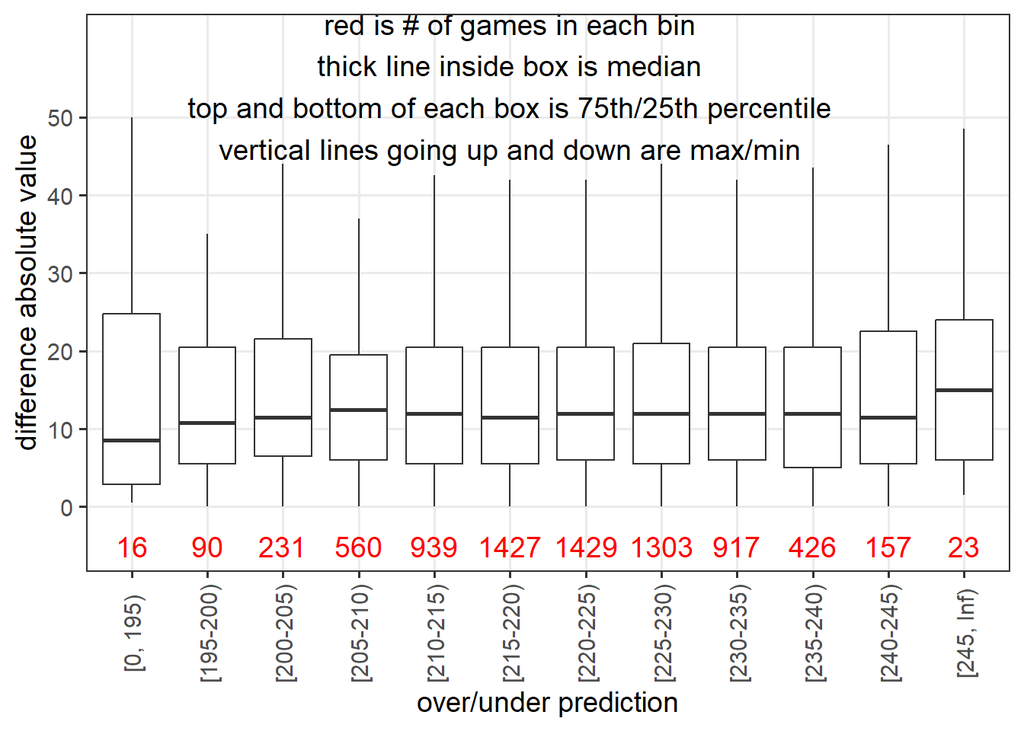

```r
ggplot(df, aes(prediction_bin, diff_abs)) +
  geom_boxplot(outlier.shape = NA) +
  theme_bw(14) +
  theme(axis.text.x = element_text(angle = 90, vjust = 0.5)) +
  xlab("over/under prediction") +
  ylab("difference absolute value") +
  scale_y_continuous(limits = c(-5, 60), breaks = seq(0, 50, 10)) +
  theme(panel.grid.minor = element_blank()) +
  geom_text(data=data.frame(), aes(x=1:12, y=-5, label=as.numeric(table(df$prediction_bin))), col='red', size=5) +
  geom_text(data = data.frame(), aes(x=6, y=54, label="red is # of games in each bin\nthick line inside box is median\ntop and bottom of each box is 75th/25th percentile\nvertical lines going up and down are max/min"), size = 5)
```

Every group looks very similar :/